# Chapter 4 - R Exercises

### d)

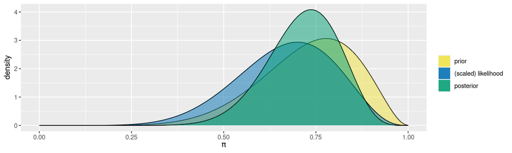

```r
plot_beta_binomial(alpha=8, beta=3, y=7, n=10)
```

Posterior only:

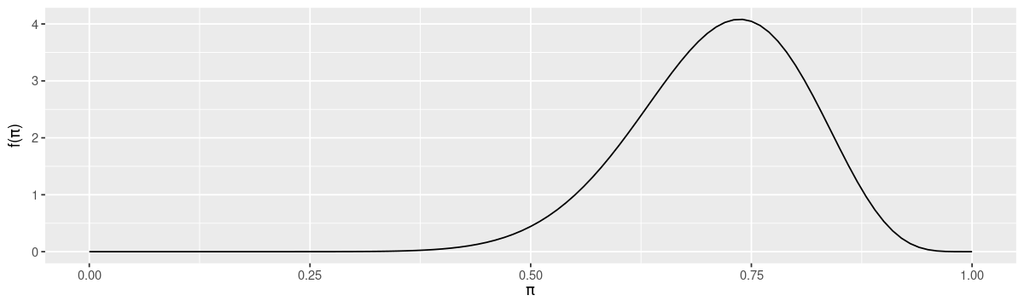

```r
plot_beta(alpha=15, beta=6)
```

### e)

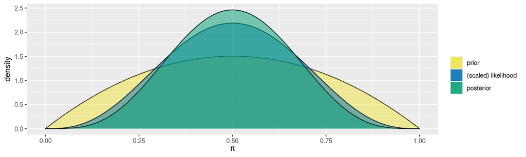

```r
plot_beta_binomial(alpha=2, beta=2, y=3, n=6)
```

Posterior only:

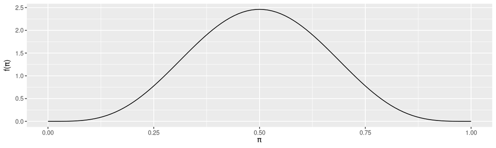

```r
plot_beta(alpha=5, beta=5)
```

### f)

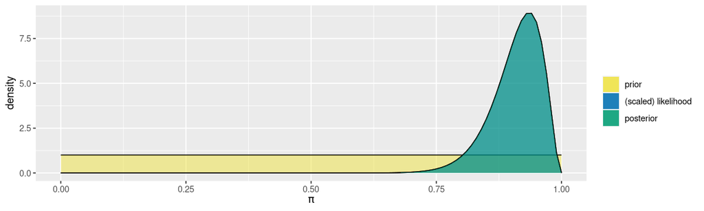

```r
plot_beta_binomial(alpha=1, beta=1, y=29, n=31)
```

Posterior only:

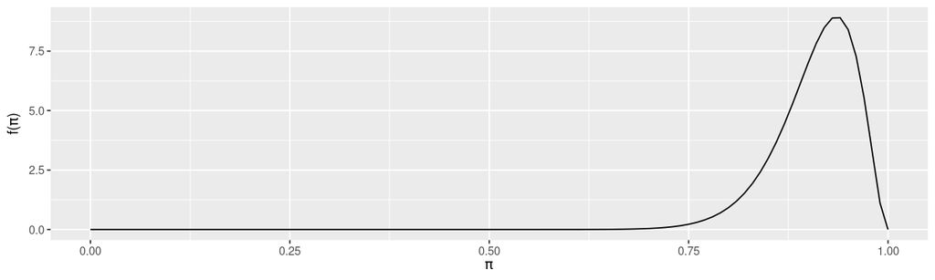

```r
plot_beta(alpha=30, beta=3)
```

## Exercise 4.11

### a)

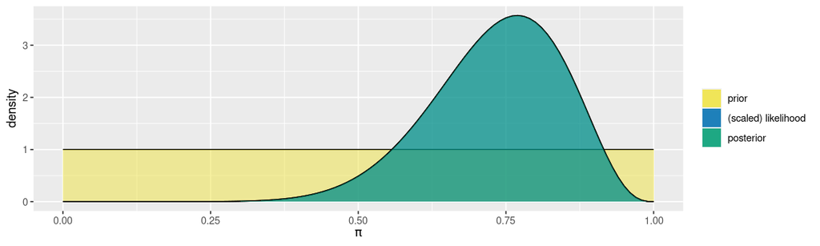

```r
plot_beta_binomial( alpha=1, beta=1, y=10, n=13 )
```

### b)

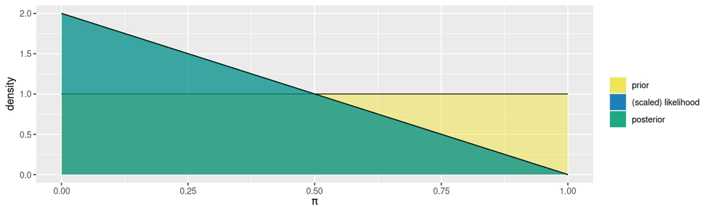

```r
plot_beta_binomial( alpha=1, beta=1, y=0, n=1 )
```

### c)

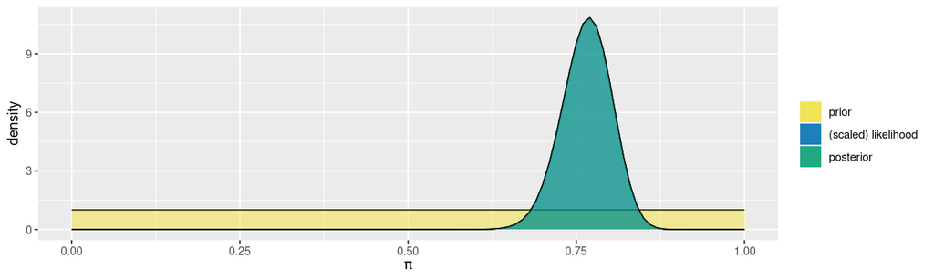

```r
plot_beta_binomial( alpha=1, beta=1, y=100, n=130 )
```

### d)

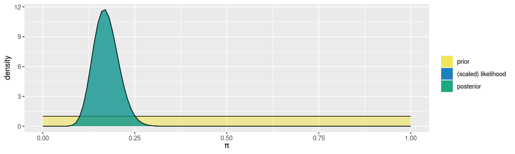

```r
plot_beta_binomial( alpha=1, beta=1, y=20, n=120 )
```

### e)

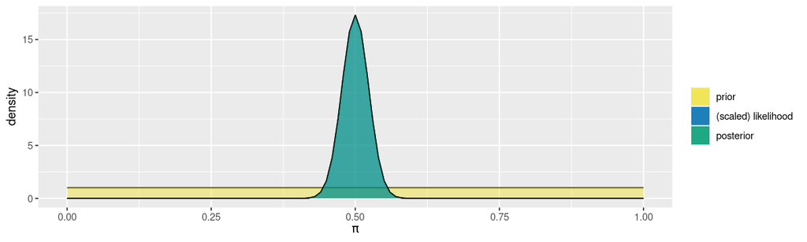

```r
plot_beta_binomial( alpha=1, beta=1, y=234, n=468 )
```

## Exercise 4.12

New prior is not flat anymore but much more concentrated towards large values of $\pi$:

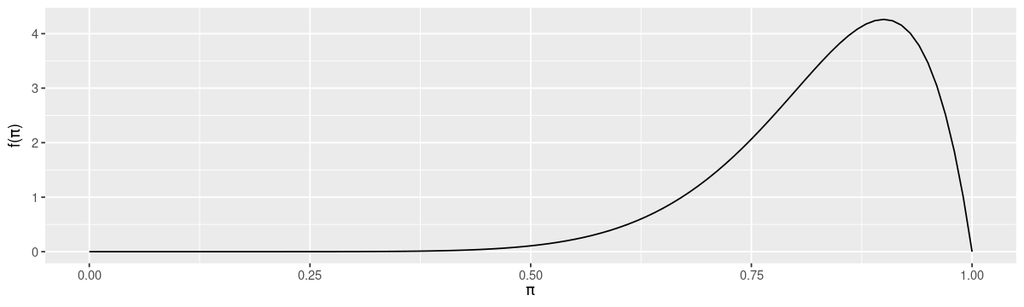

```r
plot_beta( alpha=10, beta=2 )
```

### a)

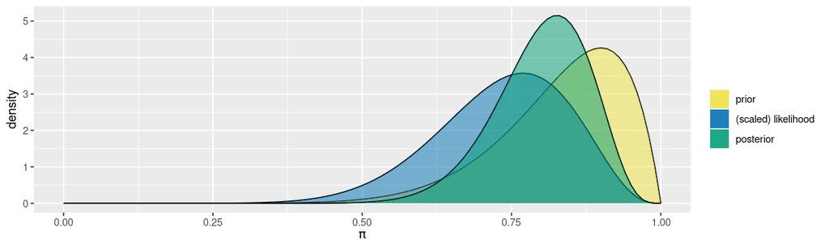

```r
plot_beta_binomial( alpha=10, beta=2, y=10, n=13 )
```

Few data are available, leading to a moderately different posterior than in 4.11 a).

### b)

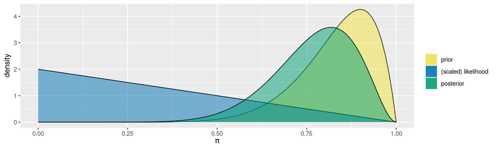

```r
plot_beta_binomial( alpha=10, beta=2, y=0, n=1 )
```

Only few data are available, leading to a very different posterior than in 4.11 b).

### c)

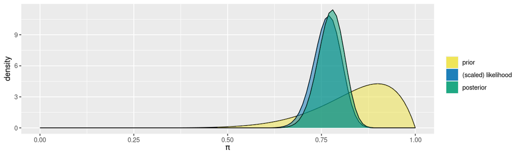

```r
plot_beta_binomial( alpha=10, beta=2, y=100, n=130 )
```

A lot of data is available, leading to almost the same posterior as in 4.11 c).

### d)

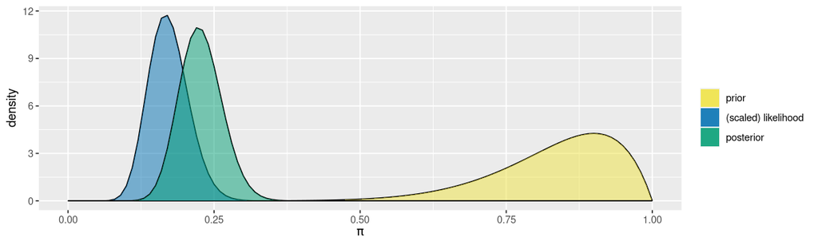

```r
plot_beta_binomial( alpha=10, beta=2, y=20, n=120 )
```

A lot of data is available, however the prior is highly biased towards high values of $\pi$, still shifting the posterior considerably compared to 4.11 d).

### e)

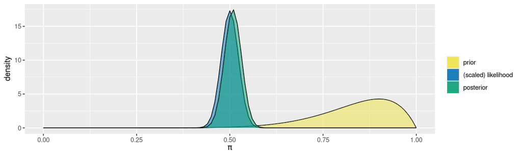

```r
plot_beta_binomial( alpha=10, beta=2, y=234, n=468 )
```

In this case the choice of prior does not matter much because such a big amount of data is available.

## Exercise 4.13

### a)

Prior:

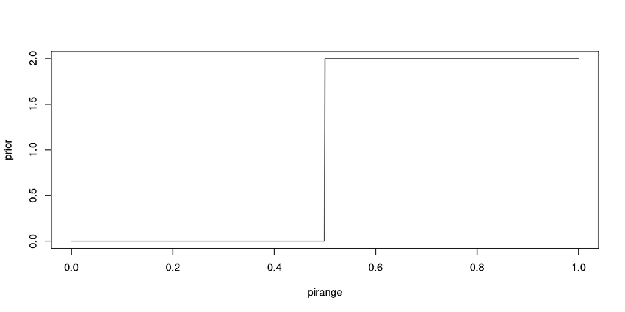

```r
pirange <- seq(0, 1, 0.001)
prior <- ifelse(pirange>=0.5, 2, 0)

options(repr.plot.width=10, repr.plot.height=5)
plot(pirange, prior, type="l")
```

### c)

Likelihood:

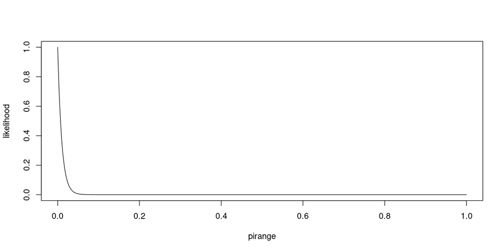

```r
likelihood <- (1-pirange)**100
plot( pirange, likelihood, type="l" )
```

Posterior:

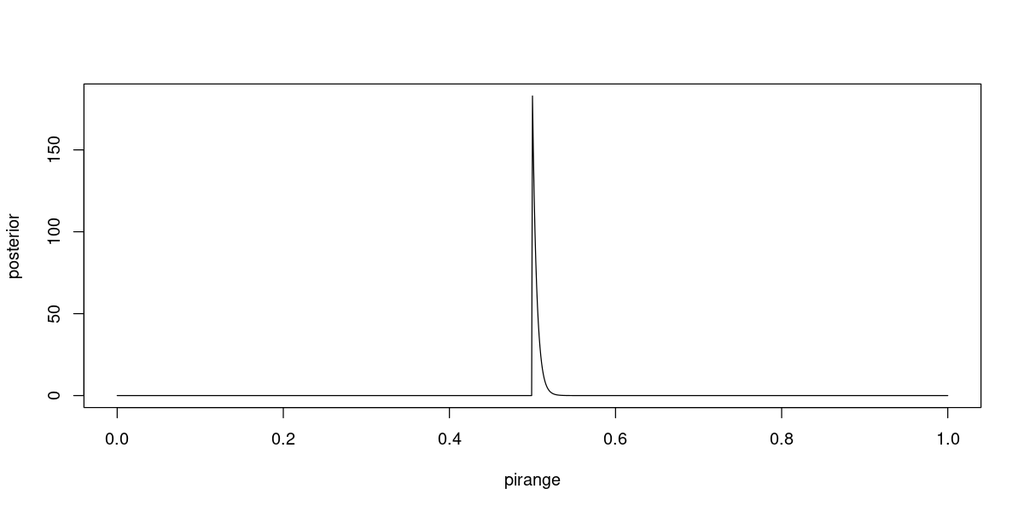

```r
posterior <- prior*(1-pirange)**100

# make sure that posterior integrates to 1
posterior <- posterior / sum( posterior*0.001 )

plot( pirange, posterior, type="l" )
```

## Exercise 4.17

### a)

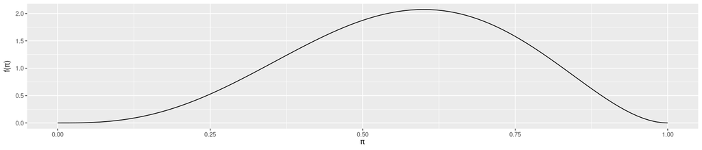

```r
options(repr.plot.width=14, repr.plot.height=3)
plot_beta( alpha=4, beta=3 )
```

### c)

First employee:

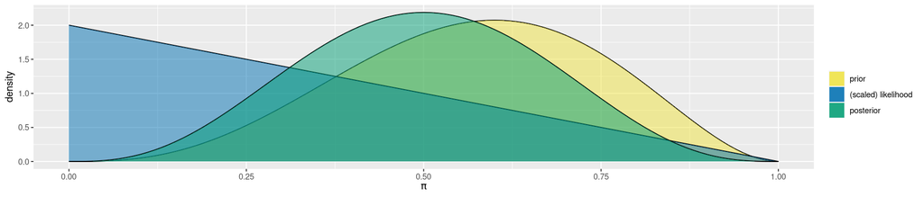

```r
plot_beta_binomial( alpha=4, beta=3, n=1, y=0 )
```

Second employee:

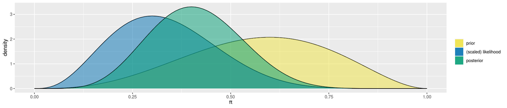

```r
plot_beta_binomial( alpha=4, beta=3, n=10, y=3 )
```

Third employee:

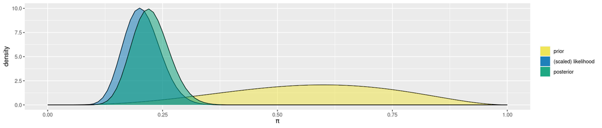

```r
plot_beta_binomial( alpha=4, beta=3, n=100, y=20 )
```

## Exercise 4.18

### b) Evolution of the information about $\pi$:

Day 0:

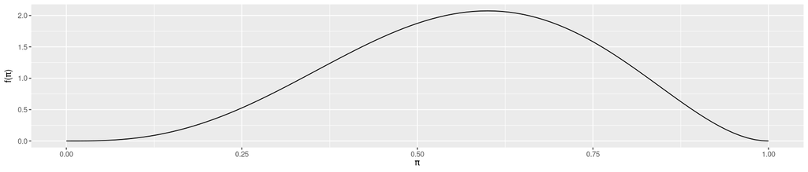

```r
plot_beta( 4, 3 )
```

```r
summarize_beta( 4, 3 )
```

A data.frame: 1 × 4

| mean <dbl> | mode <dbl> | var <dbl> | sd <dbl> |
| --- | --- | --- | --- |
| 0.5714286 | 0.6 | 0.03061224 | 0.1749636 |

Day 1:

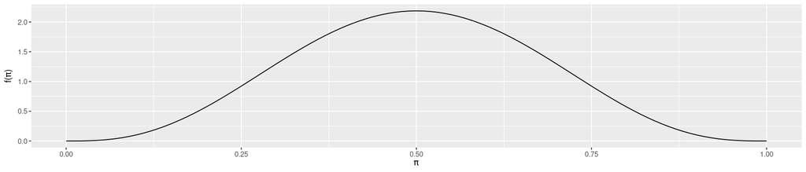

```r
plot_beta( 4, 4 )
```

```r
summarize_beta( 4, 4 )
```

A data.frame: 1 × 4

| mean <dbl> | mode <dbl> | var <dbl> | sd <dbl> |
| --- | --- | --- | --- |
| 0.5 | 0.5 | 0.02777778 | 0.1666667 |

Day 2:

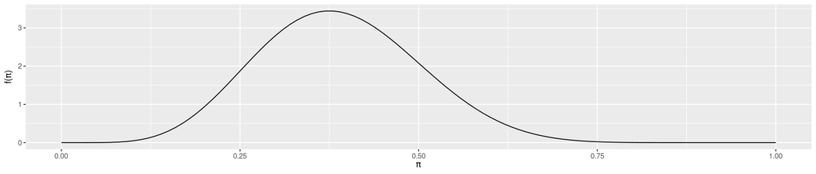

```r
plot_beta( 7, 11 )
```

```r
summarize_beta( 7, 11 )
```

A data.frame: 1 × 4

| mean <dbl> | mode <dbl> | var <dbl> | sd <dbl> |
| --- | --- | --- | --- |
| 0.3888889 | 0.375 | 0.01250812 | 0.1118397 |

Day 3:

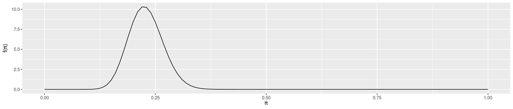

```r
plot_beta( 27, 91 )
```

```r
summarize_beta( 27, 91 )
```

A data.frame: 1 × 4

| mean <dbl> | mode <dbl> | var <dbl> | sd <dbl> |
| --- | --- | --- | --- |
| 0.2288136 | 0.2241379 | 0.00148284 | 0.03850766 |

## Exercise 4.19

### a)

```r
bechdel %>%
    filter( year==1980 ) %>%
    group_by( binary ) %>%
    summarize( n=n() )
```

A tibble: 2 × 2

| binary <chr> | n <int> |
| --- | --- |
| FAIL | 10 |
| PASS | 4 |

```r
summarize_beta_binomial(alpha=1, beta=1, y=4, n=14)
```

A data.frame: 2 × 7

| model <chr> | alpha <dbl> | beta <dbl> | mean <dbl> | mode <dbl> | var <dbl> | sd <dbl> |
| --- | --- | --- | --- | --- | --- | --- |
| prior | 1 | 1 | 0.5000 | NaN | 0.08333333 | 0.2886751 |
| posterior | 5 | 11 | 0.3125 | 0.2857143 | 0.01263787 | 0.1124183 |

### b)

```r
bechdel %>%
    filter( year==1990 ) %>%
    group_by( binary ) %>%
    summarize( n=n() )
```

A tibble: 2 × 2

| binary <chr> | n <int> |
| --- | --- |
| FAIL | 9 |
| PASS | 6 |

```r
summarize_beta_binomial(alpha=5, beta=11, y=6, n=15)
```

A data.frame: 2 × 7

| model <chr> | alpha <dbl> | beta <dbl> | mean <dbl> | mode <dbl> | var <dbl> | sd <dbl> |
| --- | --- | --- | --- | --- | --- | --- |
| prior | 5 | 11 | 0.3125000 | 0.2857143 | 0.012637868 | 0.11241827 |
| posterior | 11 | 20 | 0.3548387 | 0.3448276 | 0.007154006 | 0.08458136 |

### c)

```r
bechdel %>%
    filter( year==2000 ) %>%
    group_by( binary ) %>%
    summarize( n=n() )
```

A tibble: 2 × 2

| binary <chr> | n <int> |
| --- | --- |
| FAIL | 34 |
| PASS | 29 |

```r
summarize_beta_binomial(alpha=11, beta=20, y=29, n=63)
```

A data.frame: 2 × 7

| model <chr> | alpha <dbl> | beta <dbl> | mean <dbl> | mode <dbl> | var <dbl> | sd <dbl> |
| --- | --- | --- | --- | --- | --- | --- |
| prior | 11 | 20 | 0.3548387 | 0.3448276 | 0.007154006 | 0.08458136 |
| posterior | 40 | 54 | 0.4255319 | 0.4239130 | 0.002573205 | 0.05072677 |

### d)

```r
bechdel %>%
    filter( year %in% c(1980, 1990, 2000) ) %>%
     group_by( binary ) %>%
     summarize( n=n() )
```

A tibble: 2 × 2

| binary <chr> | n <int> |
| --- | --- |
| FAIL | 53 |
| PASS | 39 |